# Example workflow: subcellular proteome profiling on a data subset

This vignette runs the Proteome part of the analysis pipeline on a small example dataset that is included in the repository, reproduces the marker profile plot of Figure 3c and builds a ranked table of candidate protein redistributions.

Rendering it runs the complete Proteome pipeline (`01` to `06`) and takes roughly 15–30 minutes. To render it, start R in the project root and run:

```r
rmarkdown::render("vignettes/example_workflow.Rmd")
```

To re-render only the text and plots from existing results, set `run_pipeline <- FALSE` in the first chunk of this file.

## Example dataset

`example_data/input/` contains a subset of the Spectronaut protein group report used in the manuscript (PRIDE PXD067608):

- all proteins of the subcellular marker set (`Subcell_markers_selected.csv`) that were identified (639 of 650 marker entries), plus
- 500 randomly selected other proteins,
- for all 96 runs: 6 fractions × 4 conditions (`CTRL`, `Anis`, `p38`, `Zaki`; treatments as described in the manuscript) × 4 replicates.

All conditions and fractions are kept, because normalisation, imputation and the limma contrasts are computed per fraction across all conditions. The report is stored gzipped; `script/Proteome/00_path_definitions.R` uses the `.tsv.gz` file when no uncompressed report is present.

```r
library(tidyverse)
```

```r
report <- readr::read_tsv(
  list.files("example_data/input/Proteome", pattern = "\\.tsv\\.gz$", full.names = TRUE),
  show_col_types = FALSE
)

report %>%
  summarise(
    proteins = n_distinct(PG.ProteinGroups),
    runs     = n_distinct(R.FileName),
    rows     = n()
  ) %>%
  knitr::kable()
```

| proteins | runs | rows |
| --- | --- | --- |
| 1139 | 96 | 79296 |

## Run the pipeline

The input and output folders are set with environment variables, which are read by `script/Proteome/00_path_definitions.R`. Results are written to `example_data/results/`, so the results of the full dataset in `data/` are not touched.

```r
Sys.setenv(
  SUB001_RAW_DIR  = "example_data/input",
  SUB001_DATA_DIR = "example_data/results"
)
```

`run_pipeline.R` runs each script in its own R session, exactly as it would be run on its own. `core` runs only the scripts that produce result tables (no QC and figure scripts). The console output of every script is written to `logs/proteome/`.

```r
rscript <- file.path(R.home("bin"), "Rscript")
status  <- system2(rscript, c("run_pipeline.R", "proteome", "core"))
stopifnot(status == 0)
```

## Marker profiles (Figure 3c)

`script/Proteome/04_8_...RepSep_centroids.R` plots the scaled intensity profiles of the marker proteins across the six fractions (CTRL, per replicate, with the centroid of each compartment). It is run here directly so that the plot is shown in this document. When the script is run on its own (Rscript or RStudio), it also saves the plot as a PDF in `<data folder>/Proteome/Plots/`.

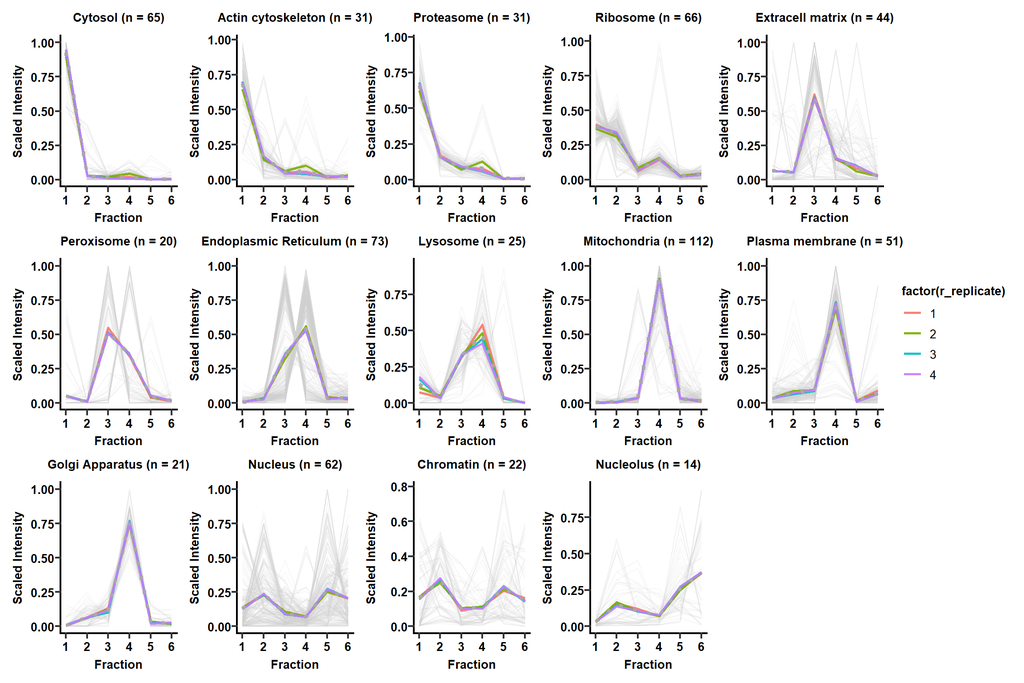

```r
fig_env <- new.env()
source(
  "script/Proteome/04_8_scaled_intensity_profile_plots_selected_markers_nonimputed_RepSep_centroids.R",
  local = fig_env
)
fig_env$combined_plot
```

Because the marker profiles are computed per protein, they are expected to look very similar to Figure 3c of the manuscript.

## Ranked candidate redistributions

`06_0_diff_and_scaled_mobility_top_movements_median.csv` contains one row per protein, treatment and redistribution between two fractions, with the limma interaction result (`diff`, `pval`, `adj_pval`) and the scores computed from the scaled intensities:

- `median_pair_mobility_score`: share of the protein signal shifted between the two fractions of the redistribution (median of the replicates),
- `median_mobility_score`: overall redistribution of the protein across all fractions it was detected in.

Candidates are first selected by the adjusted p-value of the interaction contrast and then ranked by the pair mobility score:

```r
redistributions <- readr::read_csv(
  "example_data/results/Proteome/06_0_diff_and_scaled_mobility_top_movements_median.csv",
  show_col_types = FALSE
)

candidates <- redistributions %>%
  filter(adj_pval < 0.05) %>%
  arrange(desc(median_pair_mobility_score))

candidates %>%
  count(treatment, name = "significant redistributions") %>%
  knitr::kable()
```

| treatment | significant redistributions |
| --- | --- |
| Anis | 111 |
| Zaki | 53 |
| p38 | 43 |

```r
candidates %>%
  select(pg_genes, treatment, movement, classified_movement, diff, adj_pval,
         median_pair_mobility_score, median_mobility_score) %>%
  head(20) %>%
  knitr::kable(digits = 3)
```

| pg_genes | treatment | movement | classified_movement | diff | adj_pval | median_pair_mobility_score | median_mobility_score |
| --- | --- | --- | --- | --- | --- | --- | --- |
| ARSA | p38 | Frac3->Frac4 | membrane | -3.119 | 0.011 | 0.398 | 0.334 |
| ARSA | p38 | Frac1->Frac4 | cytosol->membrane | -2.951 | 0.007 | 0.335 | 0.334 |
| BNC2 | Anis | Frac3->Frac5 | membrane->nuclear | -1.856 | 0.036 | 0.238 | 0.148 |
| FUCA1 | Anis | Frac4->Frac1 | membrane->cytosol | 2.348 | 0.014 | 0.202 | 0.105 |
| CHD2 | Anis | Frac6->Frac4 | nuclear->membrane | 2.640 | 0.001 | 0.185 | 0.091 |
| CHD2 | p38 | Frac6->Frac4 | nuclear->membrane | 2.719 | 0.001 | 0.182 | 0.078 |
| SHQ1 | p38 | Frac2->Frac1 | cytosol | 3.463 | 0.001 | 0.176 | 0.233 |
| UTRN | Zaki | Frac4->Frac2 | membrane->cytosol | 1.521 | 0.009 | 0.174 | 0.078 |
| CHD2 | p38 | Frac5->Frac4 | nuclear->membrane | 2.522 | 0.010 | 0.166 | 0.083 |
| BNC2 | Anis | Frac3->Frac2 | membrane->cytosol | 2.064 | 0.008 | 0.164 | 0.157 |
| UTRN | Anis | Frac4->Frac2 | membrane->cytosol | 1.464 | 0.006 | 0.163 | 0.073 |
| UTRN | Zaki | Frac3->Frac2 | membrane->cytosol | 1.511 | 0.016 | 0.161 | 0.090 |
| UTRN | Zaki | Frac1->Frac2 | cytosol | -1.456 | 0.042 | 0.154 | 0.090 |
| CHD2 | Anis | Frac5->Frac4 | nuclear->membrane | 2.502 | 0.011 | 0.153 | 0.097 |
| CD151 | Anis | Frac4->Frac3 | membrane | 1.996 | 0.008 | 0.147 | 0.066 |
| UTRN | p38 | Frac4->Frac2 | membrane->cytosol | 1.318 | 0.035 | 0.145 | 0.064 |
| UTRN | Zaki | Frac6->Frac2 | nuclear->cytosol | 1.430 | 0.011 | 0.140 | 0.090 |
| CD151 | p38 | Frac4->Frac3 | membrane | 1.868 | 0.019 | 0.139 | 0.070 |
| CALCOCO2 | p38 | Frac4->Frac1 | membrane->cytosol | 1.710 | 0.041 | 0.138 | 0.076 |
| UTRN | p38 | Frac5->Frac2 | nuclear->cytosol | 1.413 | 0.037 | 0.135 | 0.083 |

## Differences to the full dataset

The candidate table above is not expected to match the results of the full dataset exactly:

- **Multiple testing.** Benjamini–Hochberg adjustment is done per contrast over all proteins tested in that contrast. With about 1,100 instead of about 10,000 proteins, the number of tests is much smaller, so adjusted p-values and the set of significant redistributions differ.
- **Normalisation and imputation** are estimated from the proteins in the data. With fewer proteins, the loess normalisation and the imputed values for missing measurements change slightly.

If the results of the full dataset are available in `data/` (they are not part of the repository), the overlap is shown below.

```r
full_file <- "data/Proteome/06_0_diff_and_scaled_mobility_top_movements_median.csv"

if (file.exists(full_file)) {
  full_candidates <- readr::read_csv(full_file, show_col_types = FALSE) %>%
    filter(adj_pval < 0.05)

  key <- c("pg_protein_groups", "treatment", "movement")
  tibble(
    `significant in subset`            = nrow(candidates),
    `also significant in full dataset` = nrow(semi_join(candidates, full_candidates, by = key))
  ) %>%
    knitr::kable()
} else {
  cat("Results of the full dataset not found in data/; comparison skipped.\n")
}
```

| significant in subset | also significant in full dataset |
| --- | --- |
| 207 | 167 |